# Palmetto Binary Logistic Regression

Margaret Hammond

2/7/2022

## 1. Overview

This data focuses on the survival, growth and biomass estimates of two dominant palmetto species, *Serenoa repens* and *Sabal etonia*, populations in south-centra Florida from 1981-2017. In this task, I will be doing a binary linear regression model using plant height, canopy length, canopy width, and green leaves as predictor variables.

## 2. Explore the Data

### 2.1 Read and Wrangle the Data

```r
palmetto <- read_csv(here("data", "palmetto.csv"))

# species 1 is serenoa repends, species 2 is sabal etonia

# subset of height, length, width, green_lvs

palmetto_sub <- palmetto %>%
  select(species, height, length, width, green_lvs) %>%
  mutate(species = case_when(
    species == "1" ~ "0", #serenoa repends now 0
    species == "2" ~ "1" #sabal etonia now 1
  )) %>%
  drop_na()

palmetto_sub$species <- as.factor(palmetto_sub$species)


# class(palmetto_sub$species) checking the class of the species
```

### 2.2 Data Visualization

Explore differences in height, canopy length, canopy width, and green leaves for the two palmetto species.

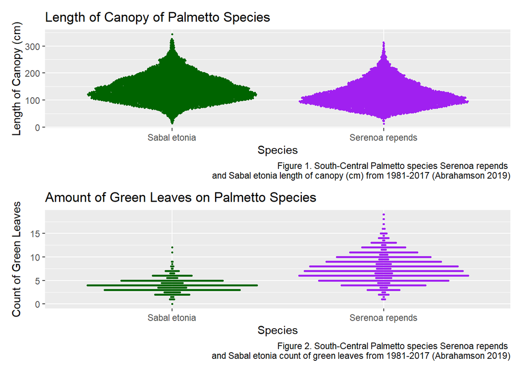

```r
palmetto_plot <- palmetto_sub %>%
  mutate(species = case_when(
    species == "0" ~ "Serenoa repends", #serenoa repends now 0
    species == "1" ~ "Sabal etonia" #sabal etonia now 1
  ))

height_plot <- ggplot(data = palmetto_sub, aes(x = species, y = height, color = species)) +
  geom_quasirandom(size = 0.5)

length_plot <- ggplot(data = palmetto_plot, aes(x = species,
                                                 y = length,
                                                 color = species)) +
  geom_quasirandom(size = 0.5, show.legend = FALSE) +
  scale_color_manual(values = c("dark green", "purple")) +
  labs(x = "Species",
       y = "Length of Canopy (cm)",
       title = "Length of Canopy of Palmetto Species",
       caption = "Figure 1. South-Central Palmetto species Serenoa repends
       and Sabal etonia length of canopy (cm) from 1981-2017 (Abrahamson 2019)")

width_plot <- ggplot(data = palmetto_sub, aes(x = species, y = width, color = species)) +
  geom_quasirandom(size = 0.5)

green_plot <- ggplot(data = palmetto_plot, aes(x = species, y = green_lvs, color = species)) +
  geom_quasirandom(size = 0.5, show.legend = FALSE) +
  scale_color_manual(values = c("dark green", "purple")) +
  labs(x = "Species",
       y = "Count of Green Leaves",
       title = "Amount of Green Leaves on Palmetto Species",
       caption = "Figure 2. South-Central Palmetto species Serenoa repends
       and Sabal etonia count of green leaves from 1981-2017 (Abrahamson 2019)")

# species 1 is serenoa repends, species 2 is sabal etonia

# length and green_lvs are the most different between the two species

length_plot / green_plot
```

For data visualization, I chose to show the difference between the two species for canopy length (cm) and green leaves count. These two variables had the biggest differences in means, and will be important predictor variables in the binary logistic regression models.

## 3. Binary Logistic Regression

### 2.1 Create the Binary Logistic Regression Models

```r
f1 <- species ~ height + length + width + green_lvs

spec_blr1 <- glm(formula = f1,
                 data = palmetto_sub,
                 family = "binomial")

f2 <- species ~ height + width + green_lvs

spec_blr2 <- glm(formula = f2,
                 data = palmetto_sub,
                 family = "binomial")

# class(palmetto_sub$species)
# levels(palmetto_sub$species)
# 0 is 0, 1 is 1. Serona is 0.



# summary(spec_blr1)
# summary(spec_blr2)

blr1_tidy <- tidy(spec_blr1)
blr2_tidy <- tidy(spec_blr2)

# aictab(list(spec_blr1, spec_blr2))
```

### 2.2 Use `caret`

Use the package `caret` to do k-fold validation of the binary logistic regression model.

```r
set.seed(123)

tr_ctrl <- trainControl(method = "repeatedcv",
                        number = 10, repeats = 10)

# Train the model
model1 <- train(f1, data = palmetto_sub,
                method = "glm",
                family = "binomial",
                trControl = tr_ctrl)
#model1

model2 <- train(f2, data = palmetto_sub,
                method = "glm",
                family = "binomial",
                trControl = tr_ctrl)
```

### 2.3 Table of Model 1

```r
spec_blr1_tidy <- tidy(spec_blr1)

spec_blr1_tidy$p.value <- ifelse(spec_blr1_tidy$p.value < .001, paste('< .001'))

# 0 is Serenoa repens
# 1 is Sabal etonia
spec_blr1_tidy %>%
  kable(col.names = c("Term",
                      "Estimate",
                      "Standard Error",
                      "Statistic",
                      "P Value"),
        caption = 'Table 1. Binary logistic regression model results for model 1, a model of plant species as a function of height, canopy length, canopy width an green leaves') %>%
  kable_classic(bootstrap_options = "striped", full_width = FALSE)
```

Table 1. Binary logistic regression model results for model 1, a model of plant species as a function of height, canopy length, canopy width an green leaves

| Term | Estimate | Standard Error | Statistic | P Value |
| --- | --- | --- | --- | --- |
| (Intercept) | 3.2266851 | 0.1420708 | 22.71180 | < .001 |
| height | -0.0292173 | 0.0023061 | -12.66984 | < .001 |
| length | 0.0458233 | 0.0018661 | 24.55600 | < .001 |
| width | 0.0394434 | 0.0021000 | 18.78227 | < .001 |
| green_lvs | -1.9084747 | 0.0388634 | -49.10728 | < .001 |

## Probability Calculations

Use `broom::augment` to find the probabilities for each plant in the original dataset, and add a column for which species your model would classify that plant as (using a 50% cutoff).

## 3. Model 1 Predictions

Create a table showing model 1’s ability to predict the palmetto species using binary linear regression.

```r
# 0 is Serenoa repens
# 1 is Sabal etonia

spec_blr1_fitted <- spec_blr1 %>%
  augment(type.predict = "response") %>%
  mutate(predict_species = case_when(
    .fitted > .5 ~ "1", # probability over .5, higher chance it will be species 1, Sabal etonia
    .fitted < .5 ~ "0"), # probability below .5, low chance it is Sabal etonia, assigned to Serenoa repens
  accuracy = case_when(
    species == predict_species ~ 1, # accurate results
    species != predict_species ~ 0), # innacurate results
  correct = case_when(
    accuracy == 1 ~ 'y',
    accuracy == 0 ~ 'n'
  ))


accuracy_sum <- spec_blr1_fitted %>%
  group_by(species) %>%
  summarize(accuracy = mean(accuracy, na.rm = TRUE) * 100)

correct_sum <- spec_blr1_fitted %>%
  group_by(correct, species) %>%
  summarize(count = n()) %>%
  pivot_wider(names_from = correct,
              values_from = count)


correct_final <- cbind(correct_sum, accuracy_sum) %>%
  select(!1) %>%
  mutate(species = case_when(
    species == 1 ~ 'Sabal etonia',
    species == 0 ~ 'Serenoa repens'
  ))

correct_final <-correct_final[, c(3, 1, 2, 4)]



#spec_count_right <- spec_blr1_fitted %>%
 # count(predict_species, species)

#spec_blr1_counts <- spec_blr1_fitted %>%
 # tabyl(species, predict_species)

#spec_proportions <- spec_blr1_counts %>%
 # mutate(species = case_when(
  #  species == "0" ~ "Serenoa repens",
   # species == "1" ~ "Sabal etonia")) %>%
#  adorn_percentages() %>%
 # adorn_pct_formatting(digits = 2) %>%
  #adorn_ns()

correct_final %>%
  kable(col.names = c(
    "Species",
    "Amount Incorrect",
    'Amount Correct',
    "Percent Correct"),
    caption = "Table 2. Probability of correct Sabal etonia and Serenoa repens species as predicted by Model 1.",
    digits = 2) %>%
  kable_classic(bootstrap_options = "striped", full_width = FALSE)
```

Table 2. Probability of correct Sabal etonia and Serenoa repens species as predicted by Model 1.

| Species | Amount Incorrect | Amount Correct | Percent Correct |
| --- | --- | --- | --- |
| Serenoa repens | 564 | 5548 | 90.77 |
| Sabal etonia | 454 | 5701 | 92.62 |

### 3.1 Probability Calculations Conclusion

Model 1 was able to predict 90.77% correct for *Serenoa repens* and 92.62% for *Sabal etonia*. Model 1 was able to predict the plant species based off of the predictor variables relatively well.

## Data Citation

Abrahamson, W.G. 2019. Survival, growth and biomass estimates of two dominant palmetto species of south-central Florida from 1981 - 2017, ongoing at 5-year intervals ver 1. Environmental Data Initiative. https://doi.org/10.6073/pasta/f2f96ec76fbbd4b9db431c79a770c4d5